# Hw3

Calvin Wong

2/19/2020

```r
library(fpp2)
library(forecast)
library(seasonal)
```

2. The plastics data set consists of the monthly sales (in thousands) of product A for a plastics manufacturer for five years.

```r
plastics
```

```
##    Jan  Feb  Mar  Apr  May  Jun  Jul  Aug  Sep  Oct  Nov  Dec
## 1  742  697  776  898 1030 1107 1165 1216 1208 1131  971  783
## 2  741  700  774  932 1099 1223 1290 1349 1341 1296 1066  901
## 3  896  793  885 1055 1204 1326 1303 1436 1473 1453 1170 1023
## 4  951  861  938 1109 1274 1422 1486 1555 1604 1600 1403 1209
## 5 1030 1032 1126 1285 1468 1637 1611 1608 1528 1420 1119 1013
```

1. Plot the time series of sales of product A. Can you identify seasonal fluctuations and/or a trend-cycle?

There is a seasonal fluctuations within a frequency of 1 year with an increasing trend.

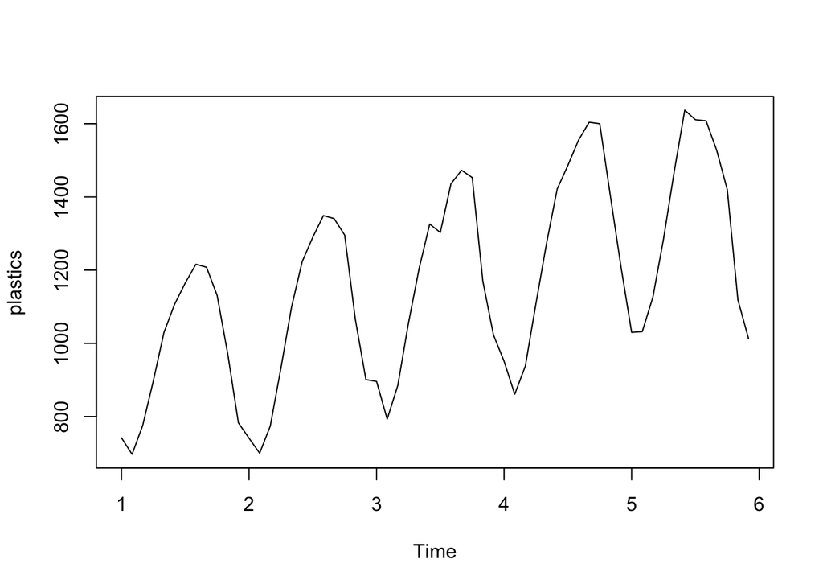

```r
plot(plastics)
```

2. Use a classical multiplicative decomposition to calculate the trend-cycle and seasonal indices.

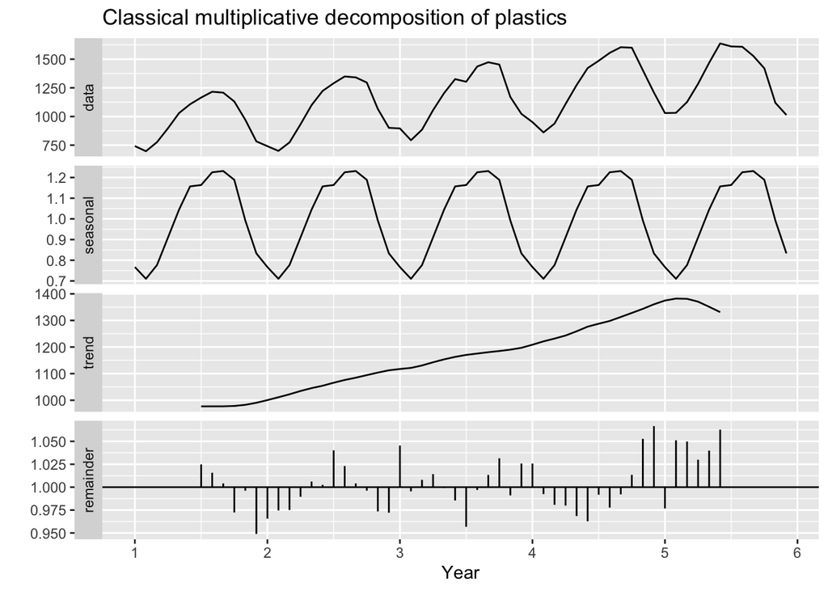

```r
plastics %>% decompose(type="multiplicative") %>%
  autoplot() + xlab("Year") +
  ggtitle("Classical multiplicative decomposition of plastics")
```

3. Do the results support the graphical interpretation from part a?

Yes, it does. Seasonality and trend is represented from part a. However, trend descend towards year 5 is better represented within this graph.

4. Compute and plot the seasonally adjusted data.

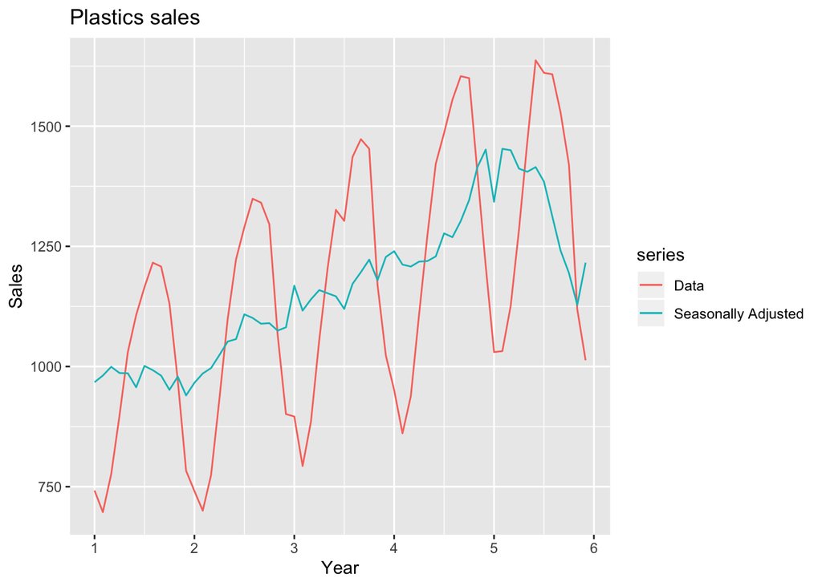

```r
mult_decomp <- plastics %>%
  decompose(type="multiplicative")

autoplot(plastics, series="Data") +
  autolayer(seasadj(mult_decomp), series="Seasonally Adjusted") +
  ggtitle("Plastics sales") +
  ylab("Sales") +
  xlab("Year")
```

5. Change one observation to be an outlier (e.g., add 500 to one observation), and recompute the seasonally adjusted data. What is the effect of the outlier?

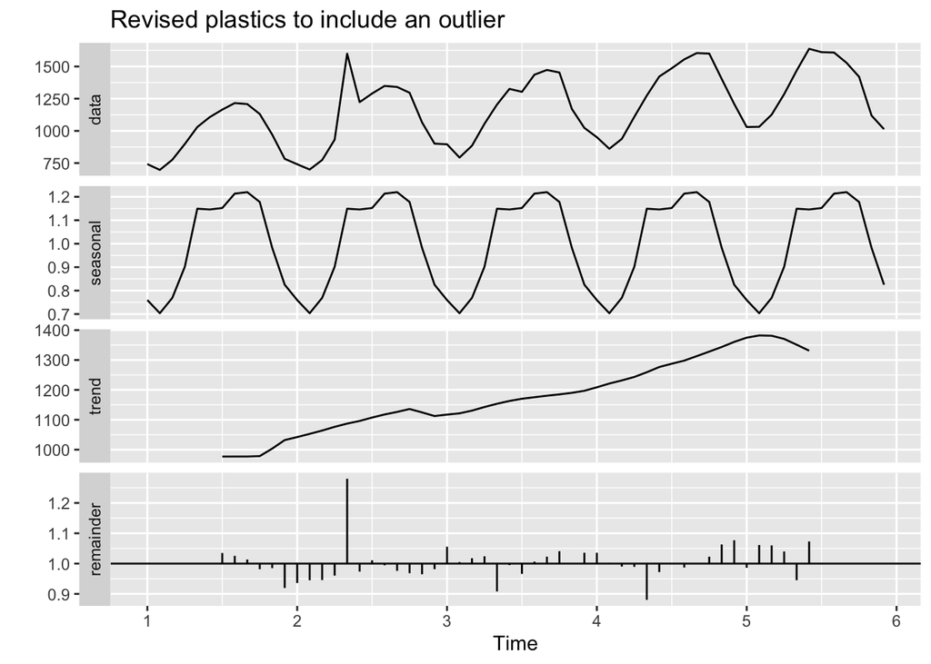

```r
plastics1 <- plastics
plastics1[17] <- plastics1[17]+500

mult_decomp2 <- plastics1 %>%
  decompose(type="multiplicative")

plastics1 %>%
decompose(type="multiplicative") %>%
autoplot() +
ggtitle("Revised plastics to include an outlier")
```

6. Does it make any difference if the outlier is near the end rather than in the middle of the time series?

Yes, the outlier changes visualization towards the end as expected. However, in this case, only the data graph is largely impacted.

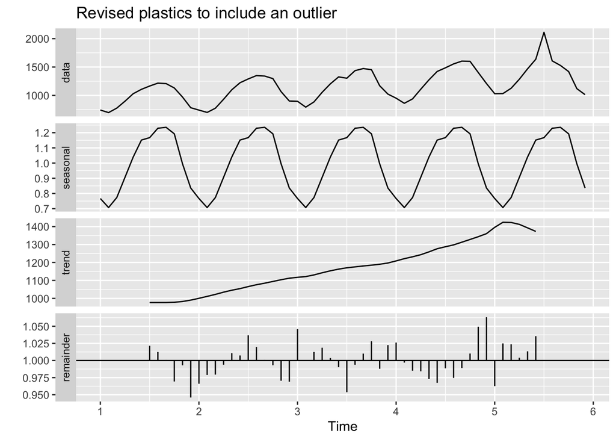

```r
plastics2 <- plastics
plastics2[55] <- plastics2[55]+500

mult_decomp2 <- plastics2 %>%
  decompose(type="multiplicative")

plastics2 %>%
decompose(type="multiplicative") %>%
autoplot() +
ggtitle("Revised plastics to include an outlier")
```

3. Recall your retail time series data (from Exercise 3 in Section 2.10). Decompose the series using X11. Does it reveal any outliers, or unusual features that you had not noticed previously?

Yes, there are outliers based on the remainder graph scattered throughout time. What is more surprising is the seasonality spikes becoming smaller over time. I also did not realize trend being affected 2006 until 2011 where it started to recover.

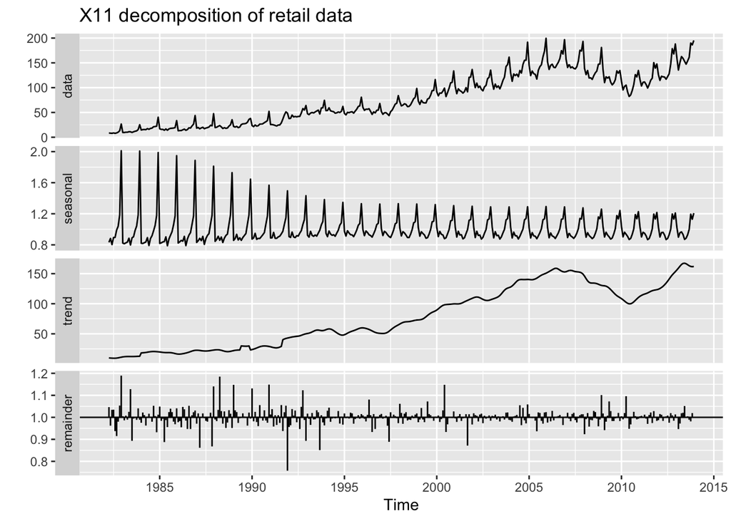

```r
retaildata <- readxl::read_excel("retail.xlsx", skip=1)
myts <- ts(retaildata[,"A3349909T"], frequency=12, start=c(1982,4))
myts %>% seas(x11="") -> myts_x11
autoplot(myts_x11) +
  ggtitle("X11 decomposition of retail data")
```